# CG3CG3

de Pedro, Joenell Conrad

Florentino, Ian Miguel

Nacu, Drixyl Reece

Ruelan, Ivan Paul

Seno, Matthew Anakin

CG3CG3

```r
library(arules)
```

```r
library(arulesViz)
```

# 1. Load the dataset and convert it to a transaction object using arules

```r
#setwd("C:/stuff/Code/R/New folder/g3-data-analysis/src") # sets ur path here
data <- read.csv("./OnlineRetail.csv")
head(data)
```

```
##   InvoiceNo StockCode                         Description Quantity
## 1    536365    85123A  WHITE HANGING HEART T-LIGHT HOLDER        6
## 2    536365     71053                 WHITE METAL LANTERN        6
## 3    536365    84406B      CREAM CUPID HEARTS COAT HANGER        8
## 4    536365    84029G KNITTED UNION FLAG HOT WATER BOTTLE        6
## 5    536365    84029E      RED WOOLLY HOTTIE WHITE HEART.        6
## 6    536365     22752        SET 7 BABUSHKA NESTING BOXES        2
##      InvoiceDate UnitPrice CustomerID        Country
## 1 12/1/2010 8:26      2.55      17850 United Kingdom
## 2 12/1/2010 8:26      3.39      17850 United Kingdom
## 3 12/1/2010 8:26      2.75      17850 United Kingdom
## 4 12/1/2010 8:26      3.39      17850 United Kingdom
## 5 12/1/2010 8:26      3.39      17850 United Kingdom
## 6 12/1/2010 8:26      7.65      17850 United Kingdom
```

```r
transactions <- as(split(data$StockCode, data$InvoiceNo), "transactions")
# inspect(transactions[1:5])
summary(transactions)
```

```
## transactions as itemMatrix in sparse format with
##  25900 rows (elements/itemsets/transactions) and
##  4071 columns (items) and a density of 0.005038226
##
## most frequent items:
##  85123A   22423  85099B   47566   20725 (Other)
##    2246    2172    2135    1706    1608  521358
##
## element (itemset/transaction) length distribution:
## sizes
##    1    2    3    4    5    6    7    8    9   10   11   12   13   14   15   16
## 5894 1587 1083  810  792  672  655  633  629  564  571  504  513  533  557  558
##   17   18   19   20   21   22   23   24   25   26   27   28   29   30   31   32
##  470  442  486  443  407  351  349  312  248  262  244  242  272  225  198  190
##   33   34   35   36   37   38   39   40   41   42   43   44   45   46   47   48
```

[output cut: 56 more lines]

# 2. Use the Apriori algorithm to find frequent itemsets with minimum support and confidence.

```r
rules <- apriori(
  transactions,
  parameter = list(
    supp = 0.02,
    conf = 0.5,
    minlen = 2
  )
)
```

```
## Apriori
##
## Parameter specification:
##  confidence minval smax arem  aval originalSupport maxtime support minlen
##         0.5    0.1    1 none FALSE            TRUE       5    0.02      2
##  maxlen target  ext
##      10  rules TRUE
##
## Algorithmic control:
##  filter tree heap memopt load sort verbose
##     0.1 TRUE TRUE  FALSE TRUE    2    TRUE
##
## Absolute minimum support count: 518
##
## set item appearances ...[0 item(s)] done [0.00s].
## set transactions ...[4071 item(s), 25900 transaction(s)] done [0.10s].
## sorting and recoding items ... [184 item(s)] done [0.00s].
## creating transaction tree ... done [0.01s].
## checking subsets of size 1 2 3 done [0.33s].
## writing ... [32 rule(s)] done [0.00s].
## creating S4 object  ... done [0.00s].
```

```r
inspect(rules[1:5])
```

```
##     lhs         rhs      support    confidence coverage   lift      count
## [1] {23202}  => {23203}  0.02000000 0.5846501  0.03420849 12.123649 518
## [2] {21928}  => {85099B} 0.02108108 0.6691176  0.03150579  8.117165 546
## [3] {85099F} => {85099B} 0.02104247 0.6566265  0.03204633  7.965633 545
## [4] {22698}  => {22699}  0.02370656 0.7655860  0.03096525 17.704177 614
## [5] {22699}  => {22698}  0.02370656 0.5482143  0.04324324 17.704177 614
```

# 3. Inspect the top rules sorted by lift.

```r
print("Top Rules sorted by lift")
```

```
## [1] "Top Rules sorted by lift"
```

```r
options(width = 40)
rules_sorted <- sort(rules, by="lift", decreasing=TRUE)
inspect(rules_sorted[1:10])
```

```
##      lhs               rhs
## [1]  {22697, 22699} => {22698}
## [2]  {22698, 22699} => {22697}
## [3]  {23300}        => {23301}
## [4]  {23301}        => {23300}
## [5]  {22697, 22698} => {22699}
## [6]  {22698}        => {22697}
## [7]  {22697}        => {22698}
## [8]  {22629}        => {22630}
## [9]  {22630}        => {22629}
## [10] {22698}        => {22699}
##      support    confidence coverage
## [1]  0.02119691 0.7002551  0.03027027
## [2]  0.02119691 0.8941368  0.02370656
## [3]  0.02119691 0.7176471  0.02953668
```

[output cut: 18 more lines]

```r
# inspect(head(rules_sorted, 10))
```

# 4. Visualize the rules using arulesViz.

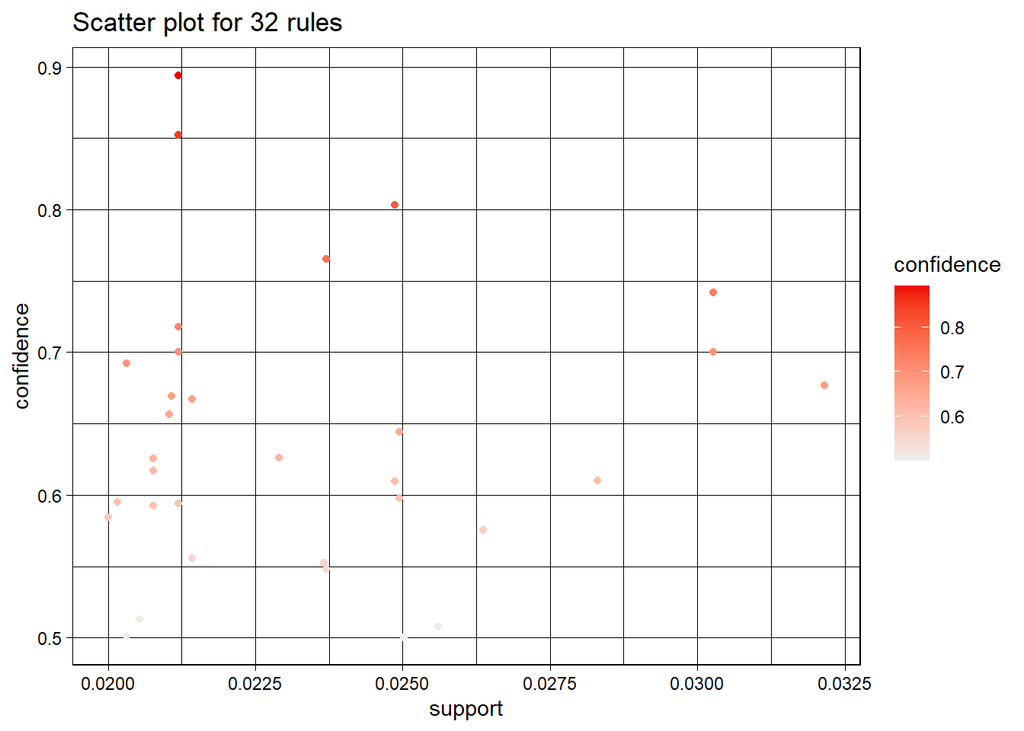

```r
plot(rules, method="scatterplot",
     measure=c("support","confidence"),
     shading="confidence")
```

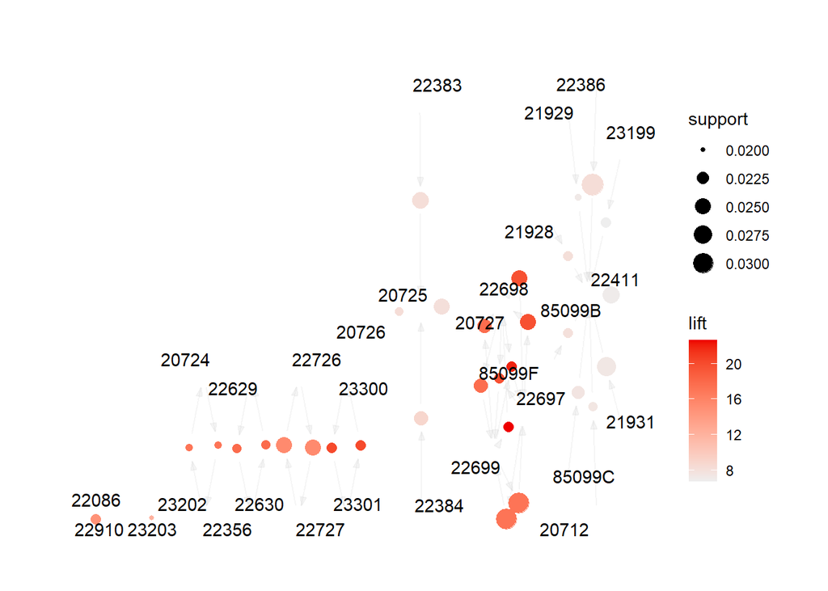

```r
plot(rules, method="graph")
```

# 5. Discuss practical business implications (e.g., product bundling, promotions).

- The analysis shows that several products are frequently purchased together. This suggests that the store can create product bundles or sets that combine these related items (e.g., teacup and saucer sets or lunch box pairs).
- The store can also use this information to design targeted promotions, such as “Buy Together and Save” or discounts when customers purchase multiple related items.
- In addition, these products could be recommended to customers during checkout or displayed together on the website, encouraging customers to add complementary items to their purchase and increasing the overall sales value.

# Discussion

## Which items are frequently purchased together? (answer comes from question 3)

Based on the rules with the highest lift and confidence, several products are commonly bought together:

- GREEN REGENCY TEACUP AND SAUCER, PINK REGENCY TEACUP AND SAUCER, and ROSES REGENCY TEACUP AND SAUCER are often purchased together. For example, when customers buy PINK REGENCY TEACUP AND SAUCER and ROSES REGENCY TEACUP AND SAUCER, there is about 89% confidence that they will also buy GREEN REGENCY TEACUP AND SAUCER.
- GARDENERS KNEELING PAD CUP OF TEA and GARDENERS KNEELING PAD KEEP CALM are frequently purchased together, with about 71% confidence that customers who buy one will buy the other.
- SPACEBOY LUNCH BOX and DOLLY GIRL LUNCH BOX are also commonly purchased together, with around 59% confidence.

These associations suggest that customers tend to purchase related or matching products, such as items from the same product set or collection.

## How could the store use this information to increase sales?

The store could use this information to design product bundling and promotional strategies. For example, items that are frequently bought together, such as the Regency teacup and saucer sets, could be offered as bundle deals or discounted sets.

The store could also display these products close to each other on the website or in-store, making it easier for customers to add multiple related items to their purchase. Additionally, “Buy together and save” promotions could encourage customers to purchase multiple items from the same product collection.

## Are there rules that suggest cross-selling opportunities?

Yes. The rules clearly show several cross-selling opportunities. For example, customers who buy one Regency teacup and saucer color variant are highly likely to purchase the other colors. This suggests that when a customer adds one teacup set to their cart, the system could recommend the other colors as complementary items. Similarly, the SPACEBOY LUNCH BOX and DOLLY GIRL LUNCH BOX are often purchased together, so the store could recommend one when the other is viewed or added to the cart. These recommendations could increase the average order value.

## What is the effect of changing support or confidence on the number of rules?

Changing the support or confidence thresholds affects how many rules are generated.

- Increasing the support or confidence values will result in fewer rules, because only the strongest and most frequent item associations will meet the stricter requirements.
- Decreasing the support or confidence values will produce more rules, since weaker or less frequent item relationships will also be included.

However, lowering these thresholds too much may generate many insignificant or less useful rules, so it is important to choose values that balance rule quantity and meaningful insights.